# Advanced ARIMA

In this section we will examine two methods that build on the ARIMA framework.

1. SARIMAX: Improve forecast accuracy by adding additional exogenous variables to SARIMA
2. Vectorized Auto Regression (VAR): Captures the dynamic interactions between multiple variables by allowing bidirectional relationships among time series.

## SARIMAX

- SARIMA relies on historical data to construct forecasts. SARIMAX also including other external variables. Including external variables can be beneficial as one may find important predictors for the target. Furthermore, the coefficients can be used to understand sensitivity or elasticity of target to changes in exogenous variable (e.g., effect of unemployment rate on GDP).
- An important caveat is that this technique relies on availability of data on exogenous variables. This is not a problem for what-if situations (e.g., X is the price of products which the retailer can control), or if exogenous variables can be forecast.

```python
import numpy as np
import pandas as pd
import matplotlib.pyplot as plt

from statsmodels.tsa.stattools import adfuller, kpss
from statsmodels.graphics.tsaplots import plot_pacf, plot_acf
from statsmodels.tsa.stattools import acf, pacf

import statsmodels.api as sm
from statsmodels.tsa.arima.model import ARIMA
from statsmodels.tsa.statespace.sarimax import SARIMAX
from statsmodels.tsa.arima_process import ArmaProcess
from statsmodels.stats.diagnostic import acorr_ljungbox
```

### GDP Data

GDP data was gathered from Federal Reserve Bank of St. Louis ([Fred](https://fred.stlouisfed.org/)). Data includes GDP and a number of macroeconomic indicators:

```python
gdp = pd.read_csv('gdp.csv', parse_dates=['DATE'], index_col = 'DATE').asfreq('QS')
train = gdp.loc[:'2015-10-01',:]
test = gdp.loc['2016-01-01':,:]
```

```python
train.columns
```

```
Index(['GDP', 'FPI', 'GCE', 'NETEXP', 'UMCSENT', 'GFDEBTN', 'PCE', 'UNRATE'], dtype='object')
```

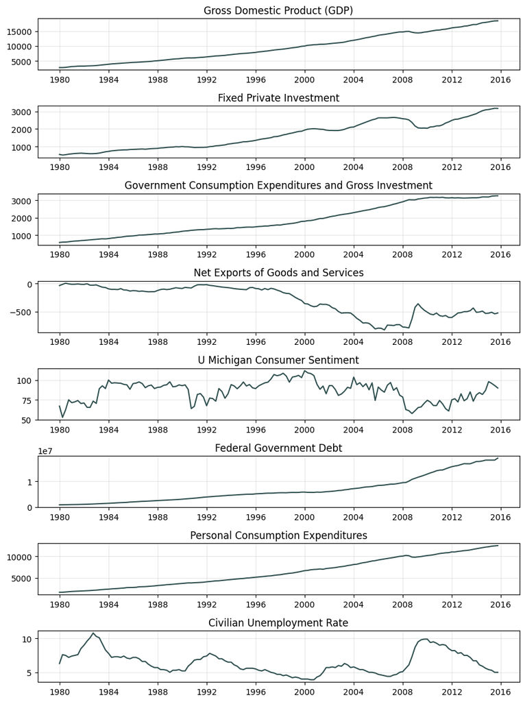

```python
fig, ax = plt.subplots(8, 1, figsize= (9,12))


ax[0].plot(train.GDP, color = 'darkslategray')
ax[0].set_title('Gross Domestic Product (GDP)')
ax[0].grid(True, alpha=0.3)

ax[1].plot(train.FPI, color = 'darkslategray')
ax[1].set_title('Fixed Private Investment')
ax[1].grid(True, alpha=0.3)

ax[2].plot(train.GCE, color = 'darkslategray')
ax[2].set_title('Government Consumption Expenditures and Gross Investment')
ax[2].grid(True, alpha=0.3)

ax[3].plot(train.NETEXP, color = 'darkslategray')
ax[3].set_title('Net Exports of Goods and Services')
ax[3].grid(True, alpha=0.3)

ax[4].plot(train.UMCSENT, color = 'darkslategray')
ax[4].set_title('U Michigan Consumer Sentiment')
ax[4].grid(True, alpha=0.3)

ax[5].plot(train.GFDEBTN, color = 'darkslategray')
ax[5].set_title('Federal Government Debt')
ax[5].grid(True, alpha=0.3)

ax[6].plot(train.PCE, color = 'darkslategray')
ax[6].set_title('Personal Consumption Expenditures')
ax[6].grid(True, alpha=0.3)

ax[7].plot(train.UNRATE, color = 'darkslategray')
ax[7].set_title('Civilian Unemployment Rate')
ax[7].grid(True, alpha=0.3)

plt.tight_layout()
plt.show()
```

### Check Stationarity

```python
adfuller(train.GDP)[0], adfuller(train.GDP)[1]
```

```
(np.float64(1.9829517471268157), np.float64(0.9986503850952133))
```

### Apply Tranformations

```python
adfuller(train.GDP.diff().dropna())[0], adfuller(train.GDP.diff().dropna())[1]
```

```
(np.float64(-3.448996210178277), np.float64(0.009397767306113141))
```

### Examine ACF, PACF

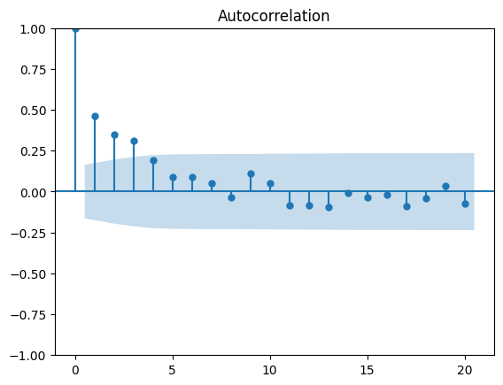

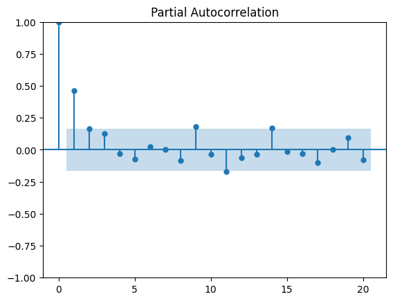

```python
plot_acf(train.GDP.diff().dropna(), lags = 20)
plot_pacf(train.GDP.diff().dropna(), lags = 20)
plt.show()
```

### Fit ARIMA

Let us fit a basic ARIMA. Since the goal is to focus on exogenous variables, we will manually specify order rather than conducting a grid search.

```python
model = SARIMAX(train.GDP, order = (1,1,1), seasonal_order=(1,1,1,4))
result = model.fit()
#result.summary()
print(result.aic)
```

```
1585.7533739371452
```

```python
pred = result.get_prediction(start = test.index[0],end = test.index[-1]).predicted_mean
from sklearn.metrics import root_mean_squared_error
root_mean_squared_error(test.GDP, pred)
```

```
3545.3202077469778
```

### Fit SARIMAX

For this section, we will introduce exogenous variables into the model. The coefficients of the exogenous variables can be interpreted in a regression sense to draw inferences about their relationship with the target, GDP.

```python
exog = ['FPI', 'GCE', 'NETEXP', 'UMCSENT', 'GFDEBTN', 'PCE', 'UNRATE']
model = SARIMAX(train.GDP, order = (1,1,1), seasonal_order=(1,1,1,4), exog = train[exog])
result = model.fit()
result.summary()
```

SARIMAX Results

| Dep. Variable: | GDP | No. Observations: | 144 |
| --- | --- | --- | --- |
| Model: | SARIMAX(1, 1, 1)x(1, 1, 1, 4) | Log Likelihood | -707.815 |
| Date: | Mon, 13 Apr 2026 | AIC | 1439.630 |
| Time: | 17:28:54 | BIC | 1474.844 |
| Sample: | 01-01-1980 | HQIC | 1453.940 |
|  | - 10-01-2015 |  |  |
| Covariance Type: | opg |  |  |

|  | coef | std err | z | P>\|z\| | [0.025 | 0.975] |
| --- | --- | --- | --- | --- | --- | --- |
| FPI | 1.3298 | 0.227 | 5.861 | 0.000 | 0.885 | 1.775 |
| GCE | 1.4791 | 0.398 | 3.712 | 0.000 | 0.698 | 2.260 |
| NETEXP | 0.4897 | 0.164 | 2.992 | 0.003 | 0.169 | 0.810 |
| UMCSENT | -0.3613 | 0.910 | -0.397 | 0.691 | -2.145 | 1.423 |
| GFDEBTN | -2.724e-05 | 5.2e-05 | -0.523 | 0.601 | -0.000 | 7.48e-05 |
| PCE | 0.3191 | 0.138 | 2.309 | 0.021 | 0.048 | 0.590 |
| UNRATE | -41.2488 | 19.142 | -2.155 | 0.031 | -78.767 | -3.731 |
| ar.L1 | -0.2268 | 0.604 | -0.376 | 0.707 | -1.410 | 0.956 |
| ma.L1 | -0.0273 | 0.620 | -0.044 | 0.965 | -1.243 | 1.188 |
| ar.S.L4 | -0.1188 | 0.234 | -0.507 | 0.612 | -0.578 | 0.340 |
| ma.S.L4 | -0.6559 | 0.232 | -2.832 | 0.005 | -1.110 | -0.202 |
| sigma2 | 2314.3458 | 463.092 | 4.998 | 0.000 | 1406.702 | 3221.989 |

| Ljung-Box (L1) (Q): | 0.00 | Jarque-Bera (JB): | 4.24 |
| --- | --- | --- | --- |
| Prob(Q): | 0.95 | Prob(JB): | 0.12 |
| Heteroskedasticity (H): | 2.84 | Skew: | -0.17 |
| Prob(H) (two-sided): | 0.00 | Kurtosis: | 3.78 |

Warnings:  
[1] Covariance matrix calculated using the outer product of gradients (complex-step).

### Examine Residuals

```
lb_stat      16.973382
lb_pvalue     0.150601
Name: 12, dtype: float64
```

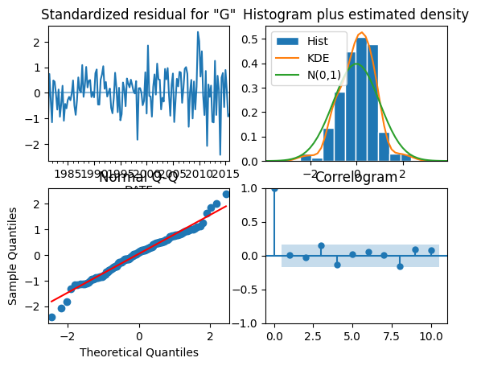

```python
print(acorr_ljungbox(result.resid, lags = 12).iloc[11,:])
result.plot_diagnostics()
plt.show()
```

### Forecast

```python
forecast = test.copy()
forecast['sarimax'] = result.get_prediction(start = test.index[0], end = test.index[-1], exog = test[exog]).predicted_mean
```

```python
root_mean_squared_error(test.GDP, forecast.sarimax)
```

```
951.7488822717271
```

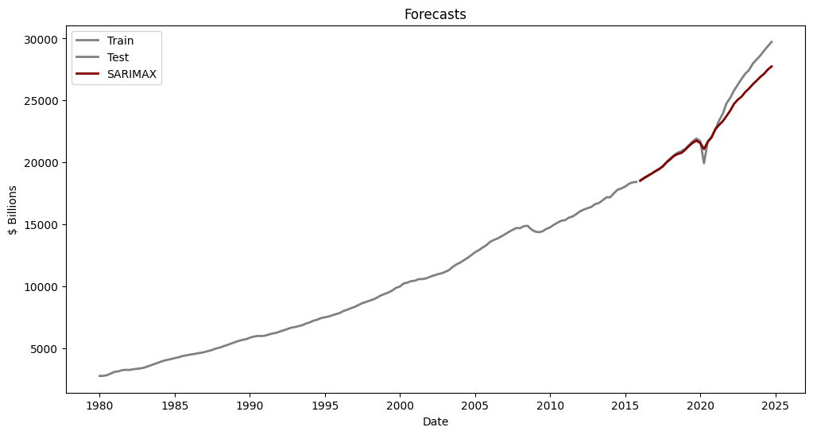

```python
plt.figure(figsize=(12,6))
plt.plot(train.index, train.GDP, label='Train', color = 'gray', lw = 2)
plt.plot(test.index, test.GDP, label='Test', color='gray', lw = 2)

plt.plot(test.index, forecast.sarimax, label='SARIMAX', color = 'maroon', lw = 2)

plt.title("Forecasts")
plt.xlabel("Date")
plt.ylabel("$ Billions")
plt.legend()
plt.show()
```

## VAR

VAR is a multivariate time series model that captures the dynamic interactions between multiple variables. In VAR models, each variable is a function of

- Its own past values
- Past values of other variables
- Error terms

### 1, 2, 3: Initial Steps

Stationarity checks, transformations and ACF, PACF plots have already been examined above.

Unlike SARIMAX(), VAR() does not do differencing within the function, so this will be carried out explicitly.

```python
from statsmodels.tsa.api import VAR
train_diff = train.diff().dropna()
train_diff.head()
```

| DATE | GDP | FPI | GCE | NETEXP | UMCSENT | GFDEBTN | PCE | UNRATE |
| --- | --- | --- | --- | --- | --- | --- | --- | --- |
| 1980-04-01 | 7.510 | -33.119 | 19.766 | 20.592 | -14.3 | 14163.0 | 10.6 | 1.3 |
| 1980-07-01 | 59.131 | 17.383 | 3.622 | 20.682 | 9.6 | 30087.0 | 61.7 | -0.1 |
| 1980-10-01 | 129.074 | 31.663 | 16.724 | -12.153 | 12.7 | 22509.0 | 71.2 | -0.3 |
| 1981-01-01 | 138.649 | 20.036 | 24.457 | -7.577 | -3.6 | 34321.0 | 51.2 | 0.2 |
| 1981-04-01 | 38.326 | 17.503 | 15.323 | 0.751 | 1.0 | 6643.0 | 31.6 | 0.1 |

### Determine Lags

VAR models lagged values of itself and other variables. In this step, we will identify the optimal number of lags to use.

```python
max_lags = min(8, len(train_diff) // 5)  # Rule of thumb
```

```python
lag_results = []
for lag in range(1, max_lags+1):
    var_model = VAR(train_diff)
    result = var_model.fit(lag)
    lag_results.append({'lag': lag,
                        'aic': result.aic,
                        'bic': result.bic})
pd.DataFrame(lag_results).set_index('lag').sort_values('aic')
```

| lag | aic | bic |
| --- | --- | --- |
| 8 | 55.467170 | 66.657858 |
| 7 | 55.791593 | 65.557554 |
| 4 | 55.923828 | 61.497217 |
| 6 | 56.111868 | 64.466849 |
| 3 | 56.250623 | 60.452969 |
| 5 | 56.298789 | 63.256320 |
| 2 | 56.765778 | 59.609972 |
| 1 | 56.878333 | 58.377062 |

### Fit VAR

```python
var_model = VAR(train_diff)
result = var_model.fit(8)
result.aic
#result.summary()
```

```
np.float64(55.46716972977227)
```

### Examine Residuals

Ljung-Box test indicates residuals of GDP are like white noise.

```python
acorr_ljungbox(result.resid.GDP, lags=[8])
```

|  | lb_stat | lb_pvalue |
| --- | --- | --- |
| 8 | 6.281558 | 0.615725 |

### Granger Causality Test

Granger causality tests to see if one time series does in fact influence the other(s). Despite the name of the test it only assesses predictive causality, not true causality. This is because we are only determining whether past values of a time series are statistically significant in predicting another time series.

A non-significant Granger Causality test indicates that forecasts do not benefit from inclusion of the variable.

```python
for i in train_diff.columns[1:]:
    p = result.test_causality('GDP', i, kind = 'f').pvalue
    print(i, np.round(p,3))
```

```
FPI 0.057
GCE 0.574
NETEXP 0.012
UMCSENT 0.778
GFDEBTN 0.214
PCE 0.126
UNRATE 0.866
```

### Forecast

```python
pred_differenced = result.forecast(train_diff.values, steps = 36)
pred_differenced = pd.DataFrame(pred_differenced).iloc[:,0]
pred_differenced.head()
```

```
0     11.080787
1    100.908052
2    144.544948
3    111.702020
4     -4.961567
Name: 0, dtype: float64
```

Since the original series was differenced, it needs to be transformed back to original level.

```python
pred = train.iloc[-1,0] + pred_differenced.cumsum()
pred.head()
```

```
0    18446.217787
1    18547.125839
2    18691.670787
3    18803.372807
4    18798.411240
Name: 0, dtype: float64
```

```python
root_mean_squared_error(test.GDP.values, pred)
```

```
3526.4969813958314
```

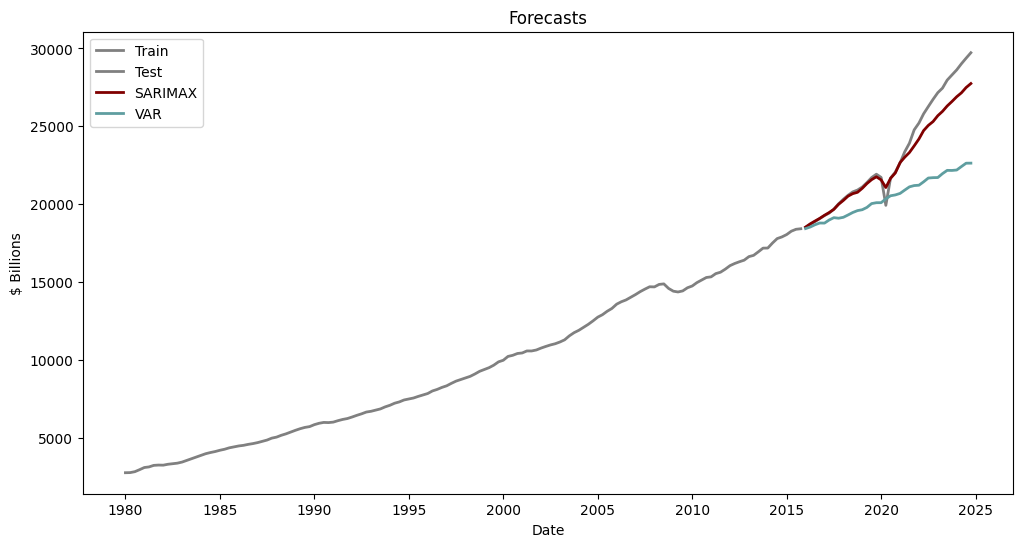

```python
plt.figure(figsize=(12,6))
plt.plot(train.index, train.GDP, label='Train', color = 'gray', lw = 2)
plt.plot(test.index, test.GDP, label='Test', color='gray', lw = 2)

plt.plot(test.index, forecast.sarimax, label='SARIMAX', color = 'maroon', lw = 2)
plt.plot(test.index, pred, label='VAR', color = 'cadetblue', lw = 2)

plt.title("Forecasts")
plt.xlabel("Date")
plt.ylabel("$ Billions")
plt.legend()
plt.show()
```

## Summary

In this note, we examined two methods that build on the ARIMA framework: SARIMAX and VAR

This file was generated using Python 3.13.5 on Windows 10 with the following libraries: matplotlib 3.10.3, numpy 2.3.1, pandas 2.3.0, scikit-learn 1.7.1, statsmodels 0.14.5